# Opgavesæt 2

2023-03-01

# Opgave 1

## Opgave 1.1

Indlæs datasættet til en dataframe med fx read.csv. Lav et summary og check at det ser OK ud. (Kik evt i scriptet til forelæsningen i uge 4, hvis det driller.)

```r
library(readr)


SAheart_data <- read_csv("SAheart.data.txt",
    col_types = cols(famhist = col_factor(levels = c("Present",
        "Absent")), chd = col_factor(levels = c("0",
        "1"))))
```

## Opgave 1.2

Fit en logistisk regression med naturlige kubiske splines for de prædiktorer der benyttes i bogens Figure5.4 (undtagen famhist).

```r
library(splines)


# Fit logistic regression with natural cubic splines and 4 knots
model <- glm(chd ~ ns(sbp, df = 4) + ns(tobacco, df = 4) + ns(ldl, df = 4) +
                ns(obesity, df = 4) + ns(age, df = 4),
             data = SAheart_data, family = binomial())

# Print summary of the model
summary(model)
```

```
##
## Call:
## glm(formula = chd ~ ns(sbp, df = 4) + ns(tobacco, df = 4) + ns(ldl,
##     df = 4) + ns(obesity, df = 4) + ns(age, df = 4), family = binomial(),
##     data = SAheart_data)
##
## Deviance Residuals:
##     Min       1Q   Median       3Q      Max
## -1.9661  -0.8748  -0.4370   0.9843   2.8347
##
## Coefficients:
##                      Estimate Std. Error z value Pr(>|z|)
## (Intercept)           -2.3963     2.2239  -1.078  0.28124
## ns(sbp, df = 4)1      -1.1445     0.8156  -1.403  0.16052
## ns(sbp, df = 4)2      -1.1224     0.7358  -1.525  0.12715
## ns(sbp, df = 4)3      -2.8200     1.9469  -1.448  0.14750
## ns(sbp, df = 4)4       1.2479     0.9657   1.292  0.19629
## ns(tobacco, df = 4)1   0.6565     0.4346   1.510  0.13092
## ns(tobacco, df = 4)2   0.5385     0.8407   0.641  0.52182
## ns(tobacco, df = 4)3   2.7901     1.0958   2.546  0.01089 *
## ns(tobacco, df = 4)4   3.0692     2.1494   1.428  0.15331
## ns(ldl, df = 4)1       1.7096     1.2535   1.364  0.17261
## ns(ldl, df = 4)2       1.9977     0.9809   2.037  0.04169 *
## ns(ldl, df = 4)3       4.0811     2.8319   1.441  0.14956
## ns(ldl, df = 4)4       2.9018     1.4524   1.998  0.04573 *
## ns(obesity, df = 4)1  -2.6815     1.5393  -1.742  0.08150 .
## ns(obesity, df = 4)2  -2.1278     1.1114  -1.914  0.05556 .
## ns(obesity, df = 4)3  -4.1262     3.4198  -1.207  0.22761
## ns(obesity, df = 4)4   0.1990     1.7629   0.113  0.91011
## ns(age, df = 4)1       2.7408     1.0702   2.561  0.01044 *
## ns(age, df = 4)2       3.2797     0.8790   3.731  0.00019 ***
## ns(age, df = 4)3       7.5578     2.4658   3.065  0.00218 **
## ns(age, df = 4)4       1.6721     0.5689   2.939  0.00329 **
## ---
## Signif. codes:  0 '***' 0.001 '**' 0.01 '*' 0.05 '.' 0.1 ' ' 1
##
## (Dispersion parameter for binomial family taken to be 1)
##
##     Null deviance: 596.11  on 461  degrees of freedom
## Residual deviance: 479.44  on 441  degrees of freedom
## AIC: 521.44
##
## Number of Fisher Scoring iterations: 6
```

## Opgave 1.3 & 1.4

Tegn de fittede kurver svarende til hver prædiktor for (passende valgte) fastholdte værdier at de øvrige prædiktorer. Da jeg bruger `visreg` bliver standardfejl allerede indregnet fra start.

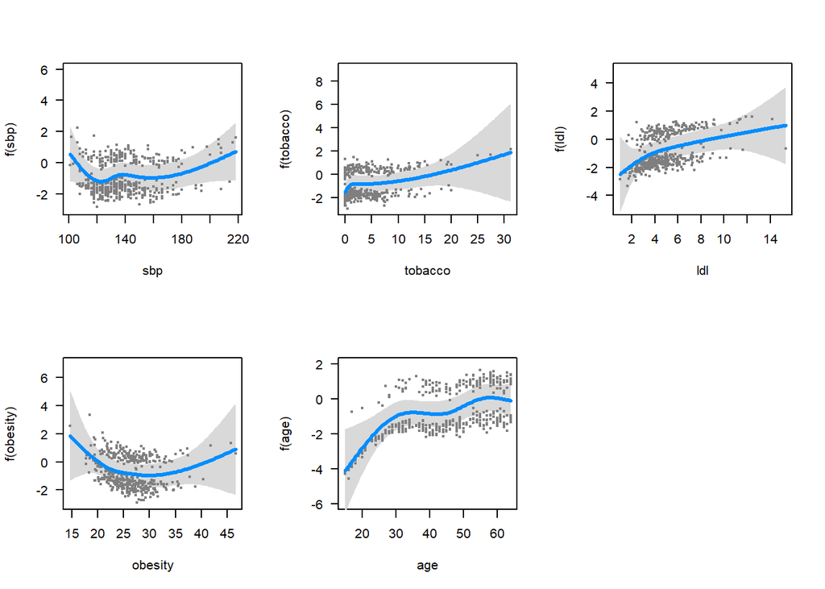

```r
# Load the visreg package
library(visreg)

# Plot the fitted curves for each predictor while holding the other predictors constant
par(mfrow = c(2, 3))
visreg(model, "sbp", ylim = c(-3, 6))
visreg(model, "tobacco", ylim = c(-3, 9))
visreg(model, "ldl", ylim = c(-5, 5))
visreg(model, "obesity", ylim = c(-3, 7))
visreg(model, "age", ylim = c(-6, 2))
```

## Opgave 1.5

Udfør tests for om prædiktorerne kan droppes fra modeller og se om I kan reproducere Table 5.1. Forsøg evt. også test for linearitet, som i scriptet fra forelæsningen.

# Opgave 2

## Opgave 2.1

Indlæs datasættet til en dataframe og lav lidt præprocessering så vi får samlet de mange frekvenser i en matrix og fjernet andre lyde end „aa“ og „ao“.

```r
# Load the splines package
library(splines)

# Fit the model
phoneme <- read.csv("./phoneme.data.txt")
phoneme <- subset(phoneme, g=="aa" | g=="ao")
ph2 <- data.frame(X=I(as.matrix(phoneme[,2:257])),
                  g= factor(phoneme$g,levels=c("aa","ao")))
fit256 <- glm(g~X, family = binomial, data=ph2)
```

## Opgave 2.2.

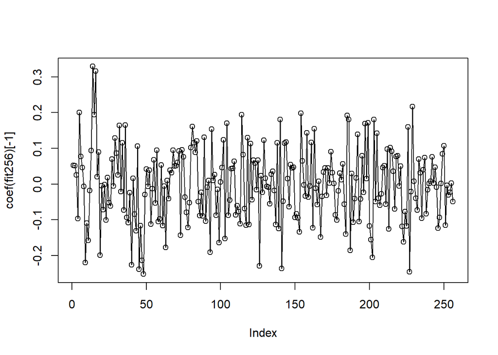

```r
plot(coef(fit256)[-1], type="o")
```

## Opgave 2.3-5

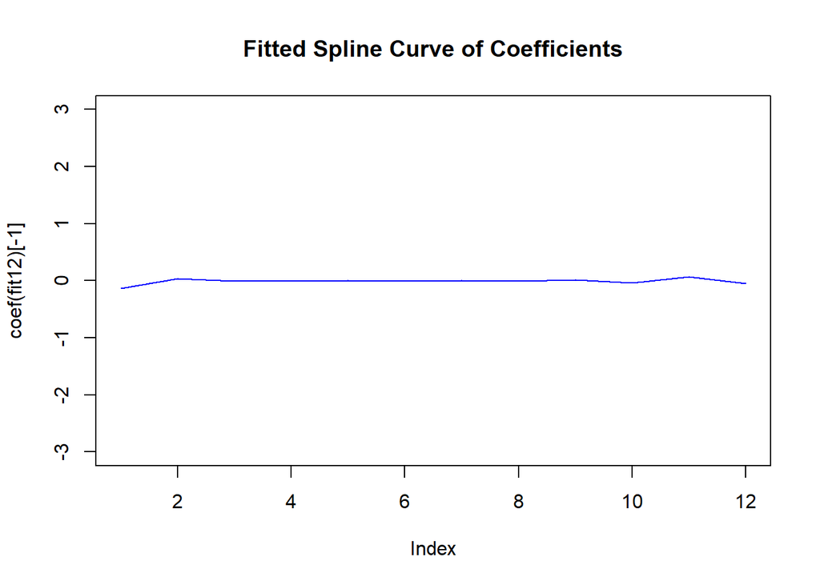

```r
# Step 4: Fit the model with natural spline parametrization
ns12 <- ns(1:256, df=12)
X_ns12 <- as.matrix(phoneme[,2:257]) %*% ns12
fit12 <- glm(g ~ X_ns12, family=binomial, data=ph2)

# Step 5: Plot the fitted spline curve of coefficients
par(mfrow=c(1,1))
plot(coef(fit12)[-1], type="l", col="blue", ylim=c(-3,3), main="Fitted Spline Curve of Coefficients")
```

## Opgave 2.6

```r
# Calculate AIC for the model with 256 predictors
AIC(fit256)
```

```
## [1] 1490.604
```

```r
# Calculate AIC for the model with 12 spline basis functions
AIC(fit12)
```

```
## [1] 1375.373
```

Vi kan se, at modellen med 12 spline-basisfunktioner har en meget lavere AIC end modellen med 256 prædiktorer. Dette tyder på, at modellen med 12 spline-basisfunktioner passer bedre til dataene.

Vi kan også tilpasse modeller med mere end 12 spline-basisfunktioner for at se, hvordan AIC ændres med flere parametre:

```r
# Fit model with 20 spline basis functions
ns20 <- ns(1:256, df=20)
X_ns20 <- as.matrix(phoneme[,2:257]) %*% ns20
fit20 <- glm(g ~ X_ns20, family=binomial, data=ph2)
AIC(fit20)
```

```
## [1] 1386.334
```

```r
# Fit model with 30 spline basis functions
ns30 <- ns(1:256, df=30)
X_ns30 <- as.matrix(phoneme[,2:257]) %*% ns30
fit30 <- glm(g ~ X_ns30, family=binomial, data=ph2)
AIC(fit30)
```

```
## [1] 1356.548
```

Går vi videre til trin 7, vil vi opdele dataene i et træningssæt og et testsæt for at evaluere modellens ydeevne på nye data.

```r
N <-nrow(ph2)
train <- sample(1:N, 1000)
test <- setdiff(1:N, train)
fit12tr <- glm(g~X %*% ns12, family = binomial, data=ph2, subset=train)
predtst <- predict(fit12tr, newdata=ph2[test,]) >.5
table(predtst, ph2$g[test])
```

```
##
## predtst  aa  ao
##   FALSE 241  89
##   TRUE   54 333
```

# Opgave 3

## Opgave 3.1 og 3.2

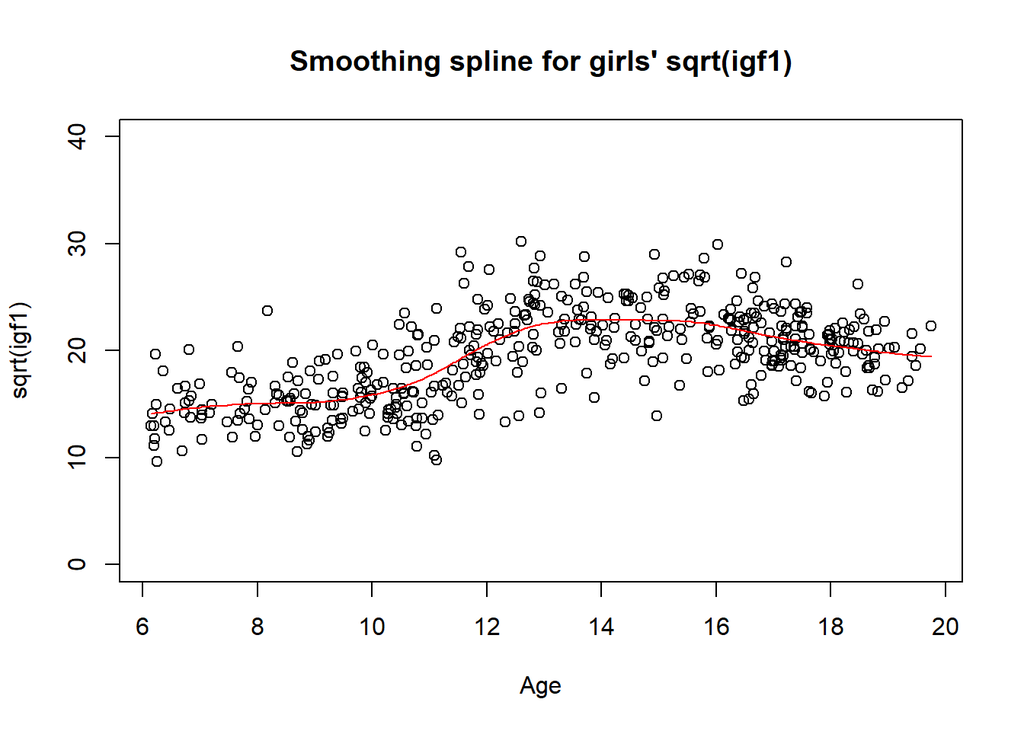

```r
library(ISwR)
library(splines)


juul_female <- subset(juul, sex==2 & !is.na(igf1) & age>6 & age <20)
juul_female_sqrtigf1 <- sqrt(juul_female$igf1)
juul_female_age <- juul_female$age
fit <- smooth.spline(juul_female_age, juul_female_sqrtigf1)
plot(juul_female_age, juul_female_sqrtigf1, main = "Smoothing spline for girls' sqrt(igf1)",
     xlab = "Age", ylab = "sqrt(igf1)", ylim = c(0, 40))
lines(fit, col = "red")
```

## Opgave 3.3

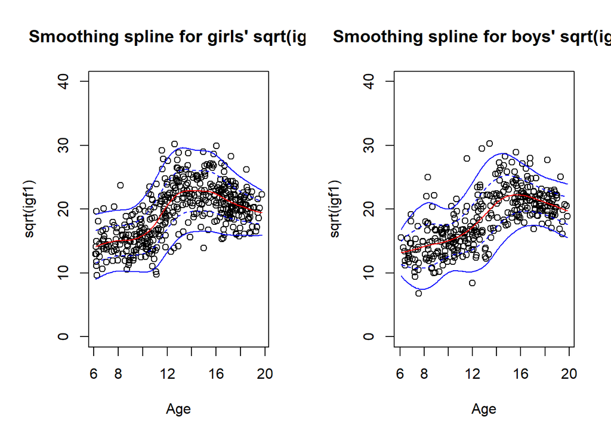

```r
# Subset data and calculate square root of igf1

juul_male <- subset(juul, sex==1 & !is.na(igf1) & age>6 & age <20)
juul_male_sqrtigf1 <- sqrt(juul_male$igf1)
juul_male_age <- juul_male$age

# Fit smoothing splines and calculate residuals
fit_female <- smooth.spline(juul_female_age, juul_female_sqrtigf1)
fit_male <- smooth.spline(juul_male_age, juul_male_sqrtigf1)

juul_female_residuals <- resid(fit_female)
juul_male_residuals <- resid(fit_male)

# Fit splines to squared residuals and calculate standard deviations
juul_female_residuals_spline <- smooth.spline(juul_female_age, juul_female_residuals^2)
juul_female_sd <- sqrt(juul_female_residuals_spline$y)

juul_male_residuals_spline <- smooth.spline(juul_male_age, juul_male_residuals^2)
juul_male_sd <- sqrt(juul_male_residuals_spline$y)

# Calculate confidence intervals
juul_female_upper_ci_1SD <- fit_female$y + 1 * juul_female_sd
juul_female_lower_ci_1SD <- fit_female$y - 1 * juul_female_sd
juul_female_upper_ci_2SD <- fit_female$y + 2 * juul_female_sd
juul_female_lower_ci_2SD <- fit_female$y - 2 * juul_female_sd

juul_male_upper_ci_1SD <- fit_male$y + 1 * juul_male_sd
juul_male_lower_ci_1SD <- fit_male$y - 1 * juul_male_sd
juul_male_upper_ci_2SD <- fit_male$y + 2 * juul_male_sd
juul_male_lower_ci_2SD <- fit_male$y - 2 * juul_male_sd

# Plotting
par(mfrow = c(1, 2), mar = c(5, 5, 4, 2) + 0.1)

# Girls plot
plot(juul_female_age, juul_female_sqrtigf1, main = "Smoothing spline for girls' sqrt(igf1)",
     xlab = "Age", ylab = "sqrt(igf1)", ylim = c(0, 40))

lines(fit_female, col = "red")

lines(fit_female$x, juul_female_upper_ci_1SD, lty = 2, col = "blue")
lines(fit_female$x, juul_female_lower_ci_1SD, lty = 2, col = "blue")
lines(fit_female$x, juul_female_upper_ci_2SD, lty = 1, col = "blue")
lines(fit_female$x, juul_female_lower_ci_2SD, lty = 1, col = "blue")

# Boys plot
plot(juul_male_age, juul_male_sqrtigf1, main = "Smoothing spline for boys' sqrt(igf1)",
     xlab = "Age", ylab = "sqrt(igf1)", ylim = c(0, 40))

lines(fit_male, col = "red")

lines(fit_male$x, juul_male_upper_ci_1SD, lty = 2, col = "blue")
lines(fit_male$x, juul_male_lower_ci_1SD, lty = 2, col = "blue")
lines(fit_male$x, juul_male_upper_ci_2SD, lty = 1, col = "blue")
lines(fit_male$x, juul_male_lower_ci_2SD, lty = 1, col = "blue")
```